# BT2201 Finance Project Notebook

This notebook quantifies the analysis we conducted to arrive at our optimal asset allocations.

## 1. Determine Investment Policy

Which products should be offered to a typical Japanese retail investor

### Risk Appetite

The typical Japanese retail investor is risk averse. Many older Japanese investors lived through the Asian Financial Crisis which saw a huge asset bubble and subsequent crash in Japanese financial markets. Those who invested money right at the peak of the asset bubble would have lost a considerable amount of money. Japan also entered many years of deflation afterwards.

Therefore, a typical Japanese retail investor is distinct from an American or European retail investor in that they have experienced more market downside and less economic euphoria. We expect that they will have a more conservative risk appetite and less tolerance for portfolio drawdown.

### Objective Function

Given the conditions described above, we choose to adopt the *Efficient Risk* or *Markowitz Portfolio*

**Fix Return and Minimise Risk**

(OR find an objective function from here) https://pyportfolioopt.readthedocs.io/en/latest/MeanVariance.html

For a start, maximise Sharpe:

$max \ \frac{E(R) - r_f}{SD(R)}$

### Amount

As stated in the preamble, investable amount is **JPY 100,000**.

### Choice of Assets

We start with the basket of ETFs provided

- BIV: US INTERMEDIATE BOND
- VCSH: US INVESTMENT GRADE BOND
- BNDX: GLOBAL BOND ETF
- VNQ: US REIT
- JP 1343: JREIT
- JP 1555: AU REIT
- SPDR: US STOCK
- VT: GLOBAL STOCK
- HVST AU: EQUITY DIVIDEND ETF AU

We choose an allocation of 40% Bond and 60% Equity to reflect the risk appetite we have chosen.

## 2. Security Analysis

Pull data for tickers described above.

```r
#install quantmod, xml2
require(quantmod)
```

```r
# ETF Data
global_etf = c('BIV', # US INTERMEDIATE BOND
            'VCSH',# US INVESTMENT GRADE BOND
            'BNDX',# GLOBAL BOND ETF
            'VNQ', #US REIT
            'VT', #GLOBAL STOCK'
            'SPY' #US STOCK (SPDR)
)

j_etf = c('1343.T',  # JREIT (JP 1343)
          '1555.T' # AU REIT (JP 1555)
)

au_etf = c('HVST.AX' #EQUITY DIVIDEND ETF AU (HVST AU)
)

getSymbols(global_etf, auto.assign = T)
```

[output not shown]

```
[1] "BIV"  "VCSH" "BNDX" "VNQ"  "VT"   "SPY"
```

```r
getSymbols(j_etf, auto.assign = T, src='yahooj')
```

```
[1] "1343.T" "1555.T"
```

```r
getSymbols(au_etf, auto.assign = T)
```

```
[1] "HVST.AX"
```

```r
# Exchange Rate Data
library(priceR)
usd_jpy = historical_exchange_rates('USD', to='JPY', start_date='2007-01-01', end_date='2021-11-03')
usd_jpy = as.xts(usd_jpy$one_USD_equivalent_to_x_JPY, order.by=as.Date(usd_jpy$date))

# Convert USA currency adjusted prices to JPY

BIV$BIV.Adjusted = BIV$BIV.Adjusted * usd_jpy
VCSH$VCSH.Adjusted = VCSH$VCSH.Adjusted * usd_jpy
BNDX$BNDX.Adjusted = BNDX$BNDX.Adjusted * usd_jpy
VNQ$BNQ.Adjusted = VNQ$VNQ.Adjusted * usd_jpy
VT$VT.Adjusted = VT$VT.Adjusted * usd_jpy
SPY$SPY.Adjusted = SPY$SPY.Adjusted * usd_jpy

aud_jpy = historical_exchange_rates('AUD', to='JPY', start_date='2007-01-01', end_date='2021-11-03')
aud_jpy = as.xts(aud_jpy$one_AUD_equivalent_to_x_JPY, order.by=as.Date(aud_jpy$date))

HVST.AX$HVST.AX.Adjusted = HVST.AX$HVST.AX.Adjusted * aud_jpy
```

Find out characteristics of each of all the tickers.

### Plots

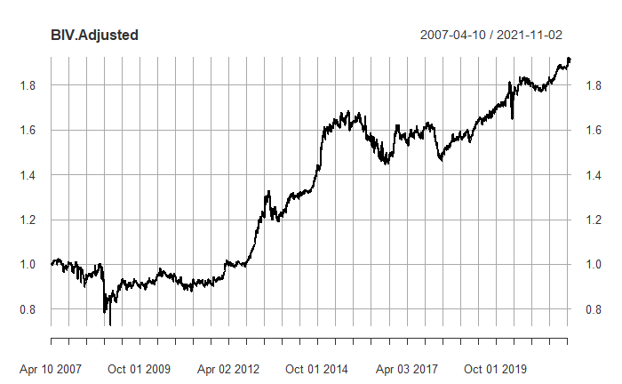

```r
tickers = list(BIV,VCSH,BNDX,VNQ,VT,SPY,`YJ1343.T`,`YJ1555.T`,HVST.AX)
name = list('BIV','VCSH','BNDX','VNQ','VT','SPY','YJ1343.T','YJ1555.T','HVST.AX')

t = BIV
init.d <- index(t)[1]
e <- t[, 6]/as.numeric(t[init.d, 6])
plot(e, main=names(e))
```

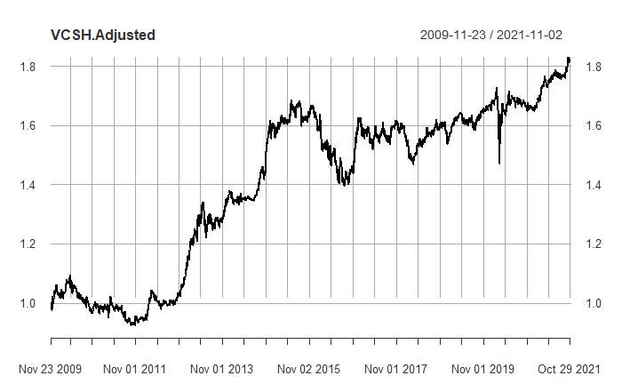

```r
t = VCSH
init.d <- index(t)[1]
e <- t[, 6]/as.numeric(t[init.d, 6])
plot(e, main=names(e))
```

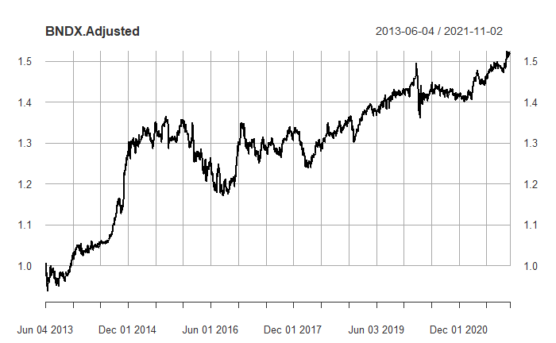

```r
t = BNDX
init.d <- index(t)[1]
e <- t[, 6]/as.numeric(t[init.d, 6])
plot(e, main=names(e))
```

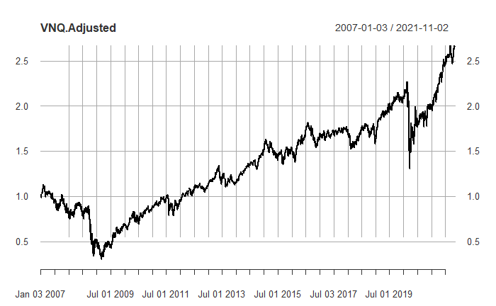

```r
t = VNQ
init.d <- index(t)[1]
e <- t[, 6]/as.numeric(t[init.d, 6])
plot(e, main=names(e))
```

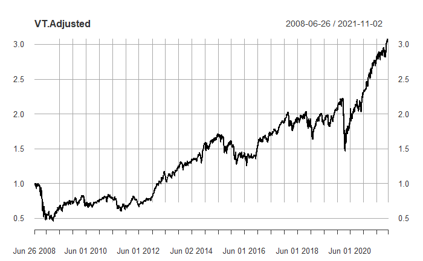

```r
t = VT
init.d <- index(t)[1]
e <- t[, 6]/as.numeric(t[init.d, 6])
plot(e, main=names(e))
```

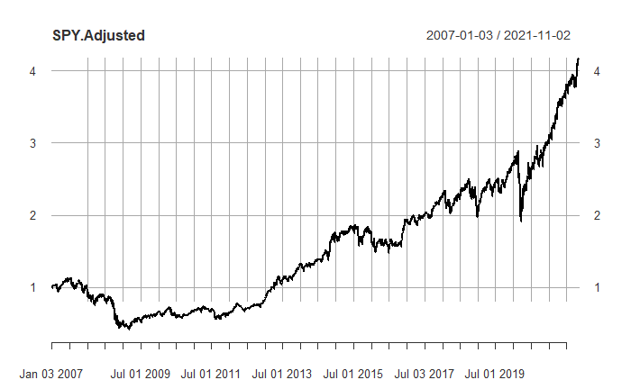

```r
t = SPY
init.d <- index(t)[1]
e <- t[, 6]/as.numeric(t[init.d, 6])
plot(e, main=names(e))
```

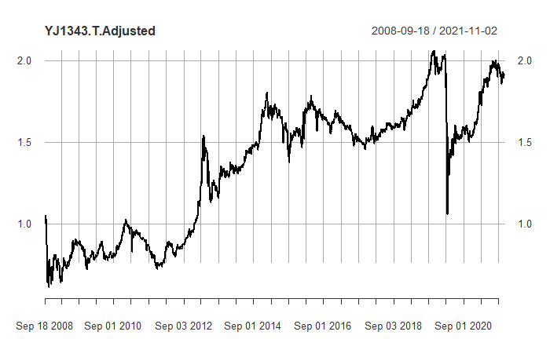

```r
t = `YJ1343.T`
init.d <- index(t)[1]
e <- t[, 6]/as.numeric(t[init.d, 6])
plot(e, main=names(e))
```

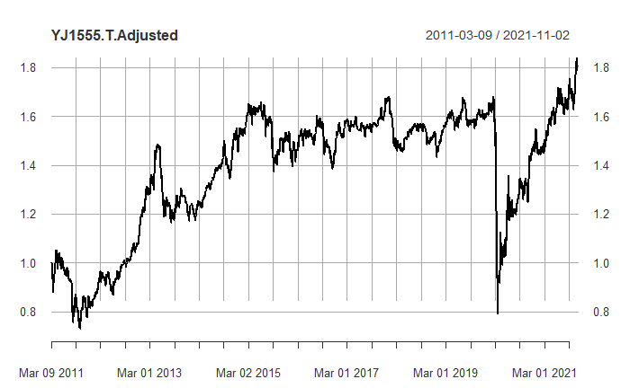

```r
t = `YJ1555.T`
init.d <- index(t)[1]
e <- t[, 6]/as.numeric(t[init.d, 6])
plot(e, main=names(e))
```

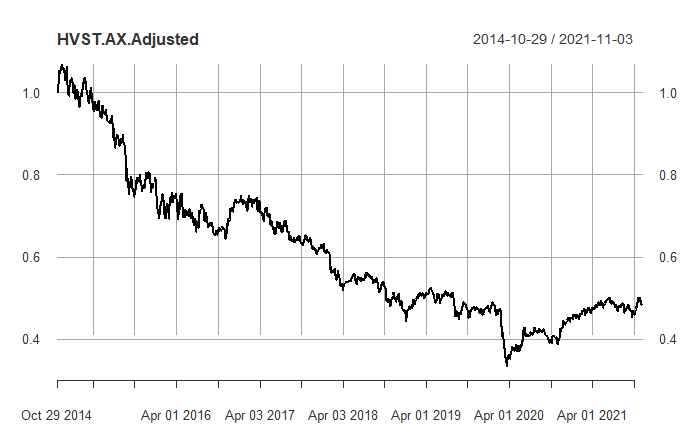

```r
t = `HVST.AX`
init.d <- index(t)[1]
e <- t[, 6]/as.numeric(t[init.d, 6])
plot(e, main=names(e))
```

### Returns

Next, calculate Returns and Volatiliy ($\mu \ and \ \sigma$) for each of the ETFs

```r
means = c()
sds = c()
returns = c()
for(i in seq(9)){
  ticker = tickers[i][[1]]
  prices_monthly <- to.monthly(ticker, name=name[i], indexAt = "lastof", OHLC = T)
  return <- ROC(Ad(prices_monthly))
  returns = cbind(returns,return)
  means = c(means, mean(return, na.rm=T))
  sds = c(sds, sd(return, na.rm=T))
}
df = data.frame(unlist(name), means, sds)
colnames(df) = c('ETF','Mu_Monthly', 'Sigma_Monthly')
df
```

| ETF | Mu_Monthly | Sigma_Monthly |
| --- | --- | --- |
| BIV | 0.003673032 | 0.02303075 |
| VCSH | 0.004340121 | 0.02263855 |
| BNDX | 0.004447784 | 0.02063740 |
| VNQ | 0.005043388 | 0.06852417 |
| VT | 0.007031259 | 0.05878820 |
| SPY | 0.007877671 | 0.05547863 |
| YJ1343.T | 0.004303177 | 0.05852825 |
| YJ1555.T | 0.004714395 | 0.06694506 |
| HVST.AX | -0.008698910 | 0.04380694 |

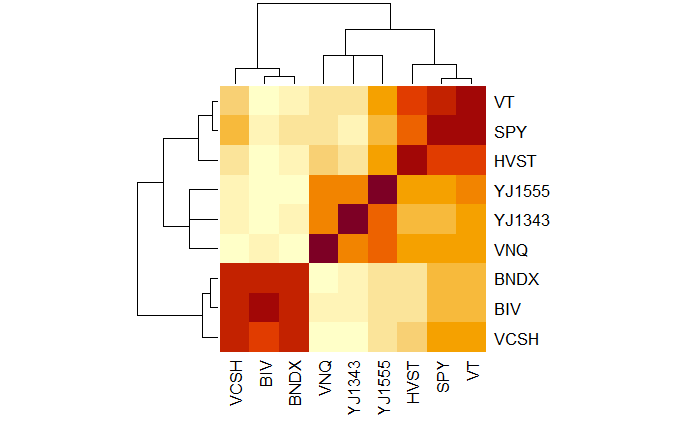

```r
library(fPortfolio)
library(purrr)
returns = data.frame(returns)

colnames(returns) <- unlist(map(colnames(returns), function(x){unlist(strsplit(x,'[.]'))[1]}))
covdata = cov(returns, use = "complete.obs")

corrdata = cor(returns, use='complete.obs')
heatmap(corrdata)
```

## 3. Portfolio Construction

```r
pSpec = portfolioSpec()
tangencyPortfolio(as.timeSeries(returns[complete.cases(returns),]))
```

```
Title:
 MV Tangency Portfolio
 Estimator:         covEstimator
 Solver:            solveRquadprog
 Optimize:          minRisk
 Constraints:       LongOnly

Portfolio Weights:
   BIV   VCSH   BNDX    VNQ     VT    SPY YJ1343 YJ1555   HVST
0.4302 0.0000 0.0000 0.0585 0.0000 0.5113 0.0000 0.0000 0.0000

Covariance Risk Budgets:
   BIV   VCSH   BNDX    VNQ     VT    SPY YJ1343 YJ1555   HVST
0.1824 0.0000 0.0000 0.0537 0.0000 0.7639 0.0000 0.0000 0.0000

Target Returns and Risks:
  mean    Cov   CVaR    VaR
0.0079 0.0324 0.0694 0.0448

Description:
 Wed Nov 03 23:48:05 2021 by user: Reverse
```

```r
# Low: 0.0144, Med: 0.0289, High: 0.0722

# Low Risk Portfolio
pSpec = portfolioSpec()
# setSolver(pSpec) <- "solveRglpk.MAD"
annual_target = 0.065
target_return = (1+annual_target)**(1/12) - 1
# annual_risk = 0.05
# target_risk = annual_risk/sqrt(12)
# setTargetRisk(pSpec) = target_risk
# setOptimize(pSpec) = 'maxReturn'
setTargetReturn(pSpec) = target_return
data = portfolioData(as.timeSeries(returns[complete.cases(returns),]))

port = efficientPortfolio(data=as.timeSeries(returns[complete.cases(returns),]), spec=pSpec)

port
```

[output not shown]

```r
# Low: 0.0144, Med: 0.0289, High: 0.0722

# Medium Risk Portfolio
pSpec = portfolioSpec()
annual_target = 0.11
target_return = (1+annual_target)**(1/12) - 1

setTargetReturn(pSpec) = target_return
data = portfolioData(as.timeSeries(returns[complete.cases(returns),]))

port = efficientPortfolio(data=as.timeSeries(returns[complete.cases(returns),]), spec=pSpec)

port
```

[output not shown]

```r
# Low: 0.0144, Med: 0.0289, High: 0.0722

# High Risk Portfolio
pSpec = portfolioSpec()
annual_target = 0.2
target_return = (1+annual_target)**(1/12) - 1

setTargetReturn(pSpec) = target_return
data = portfolioData(as.timeSeries(returns[complete.cases(returns),]))

port = efficientPortfolio(data=as.timeSeries(returns[complete.cases(returns),]), spec=pSpec)

port
```

[output not shown]

## 4. Portfolio Implementation

## 5. Portfolio Evaluation

## 6. Portfolio Revisions

### We consider a new candidate set of ETFs:

```r
new_etf= c(
  'VTI',
  'VEA',
  'VGT',
  'XLF',
  'XLE',
  'XLI',
  'XLY',
  'VAW',
  'XLP',
  'VPU'
)

getSymbols(new_etf, auto.assign=T)
```

```
pausing 1 second between requests for more than 5 symbols
pausing 1 second between requests for more than 5 symbols
pausing 1 second between requests for more than 5 symbols
pausing 1 second between requests for more than 5 symbols
pausing 1 second between requests for more than 5 symbols
pausing 1 second between requests for more than 5 symbols
```

```
 [1] "VTI" "VEA" "VGT" "XLF" "XLE" "XLI" "XLY" "VAW" "XLP" "VPU"
```

```r
VTI$VTI.Adjusted = VTI$VTI.Adjusted * usd_jpy
VEA$VEA.Adjusted = VEA$VEA.Adjusted * usd_jpy
VGT$VGT.Adjusted = VGT$VGT.Adjusted * usd_jpy
XLF$XLF.Adjusted = XLF$XLF.Adjusted * usd_jpy
XLE$XLE.Adjusted = XLE$XLE.Adjusted * usd_jpy
XLI$XLI.Adjusted = XLI$XLI.Adjusted * usd_jpy
XLY$XLY.Adjusted = XLY$XLY.Adjusted * usd_jpy
VAW$VAW.Adjusted = VAW$VAW.Adjusted * usd_jpy
XLP$XLP.Adjusted = XLP$XLP.Adjusted * usd_jpy
VPU$VPU.Adjusted = VPU$VPU.Adjusted * usd_jpy
```

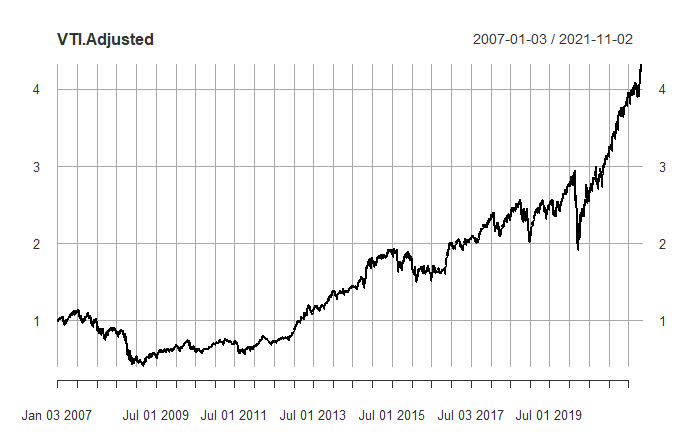

```r
new_tickers = list(VTI, VEA, VGT, XLF, XLE, XLI, XLY, VAW, XLP, VPU)
new_name = new_etf
t = VTI
init.d <- index(t)[1] # first date
e <- t[, 6]/as.numeric(t[init.d, 6]) # adjusted values / first adjusted value
plot(e, main=names(e))
```

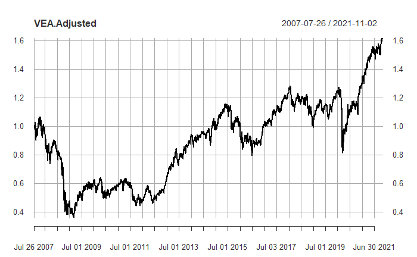

```r
t = VEA
init.d <- index(t)[1] # first date
e <- t[, 6]/as.numeric(t[init.d, 6]) # adjusted values / first adjusted value
plot(e, main=names(e))
```

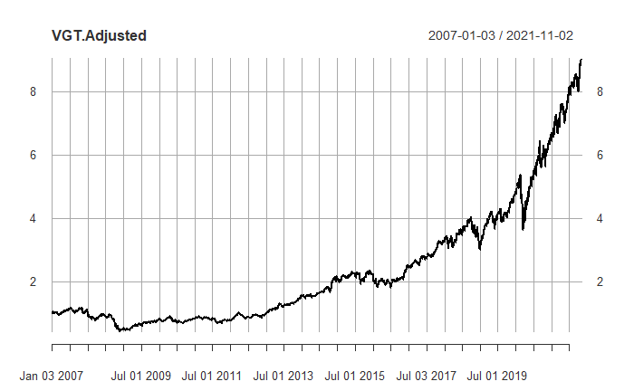

```r
t = VGT
init.d <- index(t)[1] # first date
e <- t[, 6]/as.numeric(t[init.d, 6]) # adjusted values / first adjusted value
plot(e, main=names(e))
```

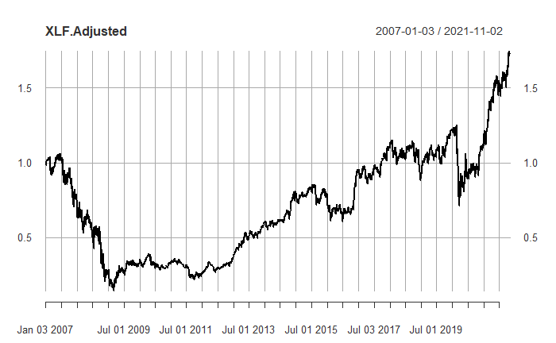

```r
t = XLF
init.d <- index(t)[1] # first date
e <- t[, 6]/as.numeric(t[init.d, 6]) # adjusted values / first adjusted value
plot(e, main=names(e))
```

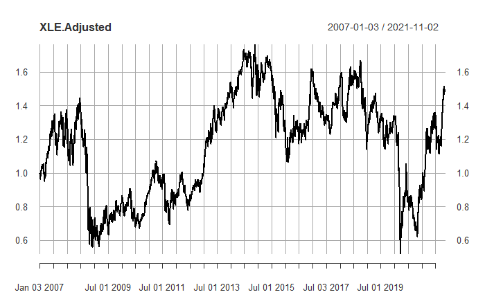

```r
t = XLE
init.d <- index(t)[1] # first date
e <- t[, 6]/as.numeric(t[init.d, 6]) # adjusted values / first adjusted value
plot(e, main=names(e))
```

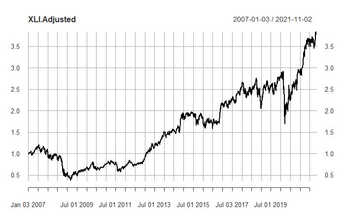

```r
t = XLI
init.d <- index(t)[1] # first date
e <- t[, 6]/as.numeric(t[init.d, 6]) # adjusted values / first adjusted value
plot(e, main=names(e))
```

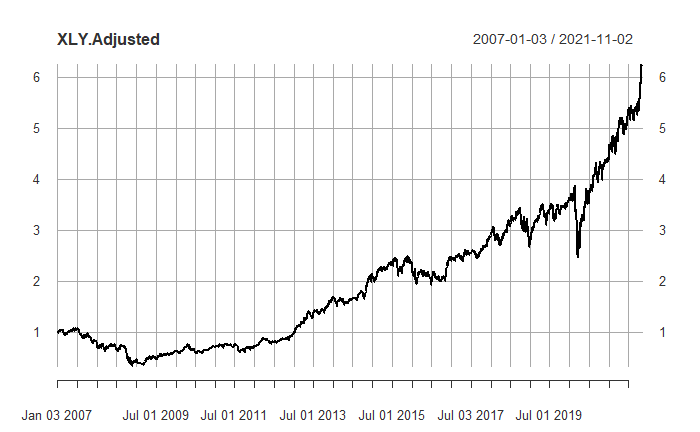

```r
t = XLY
init.d <- index(t)[1] # first date
e <- t[, 6]/as.numeric(t[init.d, 6]) # adjusted values / first adjusted value
plot(e, main=names(e))
```

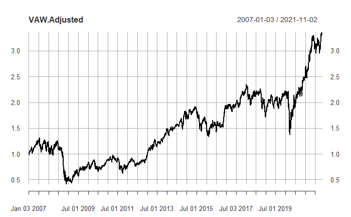

```r
t = VAW
init.d <- index(t)[1] # first date
e <- t[, 6]/as.numeric(t[init.d, 6]) # adjusted values / first adjusted value
plot(e, main=names(e))
```

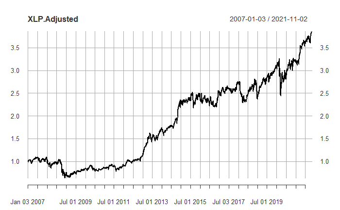

```r
t = XLP
init.d <- index(t)[1] # first date
e <- t[, 6]/as.numeric(t[init.d, 6]) # adjusted values / first adjusted value
plot(e, main=names(e))
```

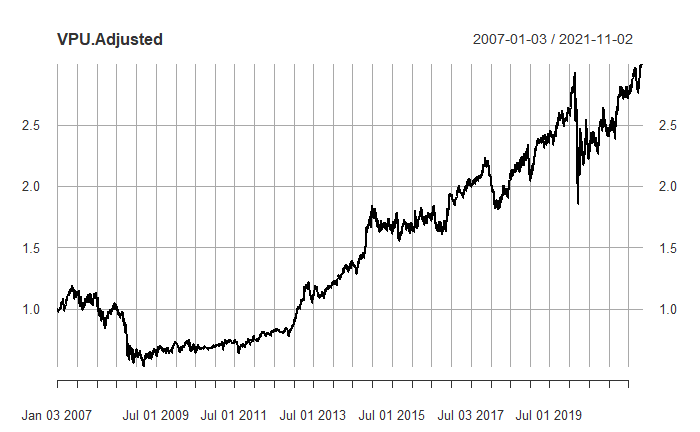

```r
t = VPU
init.d <- index(t)[1] # first date
e <- t[, 6]/as.numeric(t[init.d, 6]) # adjusted values / first adjusted value
plot(e, main=names(e))
```

```r
new_means = c()
new_sds = c()
new_returns = c()
for(i in seq(length(new_etf))){
  ticker = new_tickers[i][[1]]
  prices_monthly <- to.monthly(ticker, name=new_name[i], indexAt = "lastof", OHLC = T)
  return <- ROC(Ad(prices_monthly))
  new_returns = cbind(new_returns,return)
  new_means = c(new_means, mean(return, na.rm=T))
  new_sds = c(new_sds, sd(return, na.rm=T))
}
new_df = data.frame(unlist(new_name), new_means, new_sds)
colnames(new_df) = c('ETF','Mu_Monthly', 'Sigma_Monthly')
new_df
```

| ETF | Mu_Monthly | Sigma_Monthly |
| --- | --- | --- |
| VTI | 0.008049165 | 0.05710396 |
| VEA | 0.002768155 | 0.06145164 |
| VGT | 0.012239495 | 0.06572250 |
| XLF | 0.002998720 | 0.07954925 |
| XLE | 0.001986780 | 0.08514724 |
| XLI | 0.007417912 | 0.06567773 |
| XLY | 0.010050803 | 0.06331265 |
| VAW | 0.006433782 | 0.07115249 |
| XLP | 0.007454984 | 0.04435801 |
| VPU | 0.006110730 | 0.04785805 |

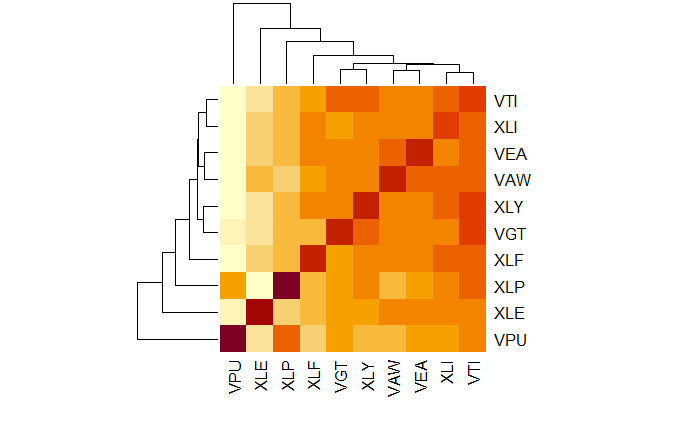

```r
library(fPortfolio)
library(purrr)
new_returns = data.frame(new_returns)

colnames(new_returns) <- unlist(map(colnames(new_returns), function(x){unlist(strsplit(x,'[.]'))[1]}))
covdata = cov(new_returns, use = "complete.obs")

corrdata = cor(new_returns, use='complete.obs')
heatmap(corrdata)
```

```r
all_returns = cbind(returns, new_returns)
all_returns
```

[output not shown]

[output cut: 169 more lines]

```r
data = portfolioData(as.timeSeries(all_returns[complete.cases(all_returns),]))
port = tangencyPortfolio(data=data)

port
```

```
Title:
 MV Tangency Portfolio
 Estimator:         covEstimator
 Solver:            solveRquadprog
 Optimize:          minRisk
 Constraints:       LongOnly

Portfolio Weights:
   BIV   VCSH   BNDX    VNQ     VT    SPY YJ1343 YJ1555   HVST    VTI    VEA    VGT    XLF    XLE    XLI    XLY    VAW    XLP    VPU
0.0000 0.0000 0.0000 0.0000 0.0000 0.0000 0.0000 0.0000 0.0000 0.0000 0.0000 0.8454 0.0000 0.0000 0.0000 0.0000 0.0000 0.0000 0.1546

Covariance Risk Budgets:
   BIV   VCSH   BNDX    VNQ     VT    SPY YJ1343 YJ1555   HVST    VTI    VEA    VGT    XLF    XLE    XLI    XLY    VAW    XLP    VPU
0.0000 0.0000 0.0000 0.0000 0.0000 0.0000 0.0000 0.0000 0.0000 0.0000 0.0000 0.9295 0.0000 0.0000 0.0000 0.0000 0.0000 0.0000 0.0705

Target Returns and Risks:
  mean    Cov   CVaR    VaR
0.0169 0.0527 0.1016 0.0823

Description:
 Thu Nov 04 00:03:12 2021 by user: Reverse
```

```r
# Low: 0.0144, Med: 0.0289, High: 0.0722
# Low Risk Portfolio
pSpec = portfolioSpec()
annual_target = 0.03
target_return = (1+annual_target)**(1/12) - 1

setTargetReturn(pSpec) = target_return
data = portfolioData(as.timeSeries(all_returns[complete.cases(all_returns),]))
port = efficientPortfolio(data=data, spec=pSpec)

port
```

```
Title:
 MV Efficient Portfolio
 Estimator:         covEstimator
 Solver:            solveRquadprog
 Optimize:          minRisk
 Constraints:       LongOnly

Portfolio Weights:
   BIV   VCSH   BNDX    VNQ     VT    SPY YJ1343 YJ1555   HVST    VTI    VEA    VGT    XLF    XLE    XLI    XLY    VAW    XLP    VPU
0.8544 0.0000 0.0000 0.0000 0.0000 0.0000 0.0770 0.0000 0.0686 0.0000 0.0000 0.0000 0.0000 0.0000 0.0000 0.0000 0.0000 0.0000 0.0000

Covariance Risk Budgets:
   BIV   VCSH   BNDX    VNQ     VT    SPY YJ1343 YJ1555   HVST    VTI    VEA    VGT    XLF    XLE    XLI    XLY    VAW    XLP    VPU
0.8331 0.0000 0.0000 0.0000 0.0000 0.0000 0.0767 0.0000 0.0902 0.0000 0.0000 0.0000 0.0000 0.0000 0.0000 0.0000 0.0000 0.0000 0.0000

Target Returns and Risks:
  mean    Cov   CVaR    VaR
0.0025 0.0193 0.0440 0.0325

Description:
 Thu Nov 04 00:05:18 2021 by user: Reverse
```

```r
# Low: 0.0144, Med: 0.0289, High: 0.0722
# Medium Risk Portfolio
pSpec = portfolioSpec()
annual_target = 0.14
target_return = (1+annual_target)**(1/12) - 1
#
setTargetReturn(pSpec) = target_return
# data = portfolioData(as.timeSeries(returns[complete.cases(returns),]))
data = portfolioData(as.timeSeries(all_returns[complete.cases(all_returns),]))
port = efficientPortfolio(data=data, spec=pSpec, constraints=c('maxW[1:19]=0.2'))

port
```

```
Title:
 MV Efficient Portfolio
 Estimator:         covEstimator
 Solver:            solveRquadprog
 Optimize:          minRisk
 Constraints:       maxW

Portfolio Weights:
   BIV   VCSH   BNDX    VNQ     VT    SPY YJ1343 YJ1555   HVST    VTI    VEA    VGT    XLF    XLE    XLI    XLY    VAW    XLP    VPU
0.2000 0.0000 0.0057 0.0313 0.0000 0.1630 0.0000 0.0000 0.0000 0.0000 0.0000 0.2000 0.0000 0.0000 0.0000 0.2000 0.0000 0.0000 0.2000

Covariance Risk Budgets:
   BIV   VCSH   BNDX    VNQ     VT    SPY YJ1343 YJ1555   HVST    VTI    VEA    VGT    XLF    XLE    XLI    XLY    VAW    XLP    VPU
0.0647 0.0000 0.0021 0.0244 0.0000 0.2009 0.0000 0.0000 0.0000 0.0000 0.0000 0.2770 0.0000 0.0000 0.0000 0.2750 0.0000 0.0000 0.1559

Target Returns and Risks:
  mean    Cov   CVaR    VaR
0.0110 0.0390 0.0820 0.0577

Description:
 Thu Nov 04 00:06:46 2021 by user: Reverse
```

```r
# Low: 0.0144, Med: 0.0289, High: 0.0722
# High Risk Portfolio
pSpec = portfolioSpec()
annual_target = 0.16
target_return = (1+annual_target)**(1/12) - 1
#
setTargetReturn(pSpec) = target_return
# data = portfolioData(as.timeSeries(returns[complete.cases(returns),]))
data = portfolioData(as.timeSeries(all_returns[complete.cases(all_returns),]))
port = efficientPortfolio(data=data, spec=pSpec, constraints=c('maxW[1:19]=0.2'))

port
```

```
Title:
 MV Efficient Portfolio
 Estimator:         covEstimator
 Solver:            solveRquadprog
 Optimize:          minRisk
 Constraints:       maxW

Portfolio Weights:
   BIV   VCSH   BNDX    VNQ     VT    SPY YJ1343 YJ1555   HVST    VTI    VEA    VGT    XLF    XLE    XLI    XLY    VAW    XLP    VPU
 0.049  0.000  0.000  0.000  0.000  0.200  0.000  0.000  0.000  0.151  0.000  0.200  0.000  0.000  0.000  0.200  0.000  0.000  0.200

Covariance Risk Budgets:
   BIV   VCSH   BNDX    VNQ     VT    SPY YJ1343 YJ1555   HVST    VTI    VEA    VGT    XLF    XLE    XLI    XLY    VAW    XLP    VPU
0.0124 0.0000 0.0000 0.0000 0.0000 0.2153 0.0000 0.0000 0.0000 0.1661 0.0000 0.2409 0.0000 0.0000 0.0000 0.2395 0.0000 0.0000 0.1257

Target Returns and Risks:
  mean    Cov   CVaR    VaR
0.0124 0.0454 0.0980 0.0728

Description:
 Thu Nov 04 00:08:42 2021 by user: Reverse
```

# Efficient Frontier Plot

```r
setNFrontierPoints(pSpec) <- 20

longFrontier <- portfolioFrontier(data = data, spec = pSpec)

col = qualiPalette(30, "Set1")
tailoredFrontierPlot(longFrontier, return = "mean", risk = "Cov")
grid()
```

[figure not shown]

```r
singleAssetPoints(longFrontier, col='red')
```

# Experimentation with Target Risk and Short Selling (for screenshots)

```r
pSpec = portfolioSpec()
annual_risk = 0.05
target_risk = annual_risk/sqrt(12)
setTargetRisk(pSpec) = target_risk
data = portfolioData(as.timeSeries(returns[complete.cases(returns),]))
port = maxreturnPortfolio(data, spec=pSpec)

port
```

[output not shown]

```r
pSpec = portfolioSpec()
annual_risk = 0.1
target_risk = annual_risk/sqrt(12)
setTargetRisk(pSpec) = target_risk
data = portfolioData(as.timeSeries(returns[complete.cases(returns),]))
port = maxreturnPortfolio(data, spec=pSpec)

port
```

[output not shown]

```r
pSpec = portfolioSpec()
annual_risk = 0.1
target_risk = annual_risk/sqrt(12) #0.0289
setSolver(pSpec) = 'solveRshortExact'
setTargetRisk(pSpec) = target_risk
data = portfolioData(as.timeSeries(returns[complete.cases(returns),]))
port = maxreturnPortfolio(data, spec=pSpec)
print(target_risk)
port
```

[output not shown]

```r
pSpec = portfolioSpec()
annual_target = 0.1
target_return = (1+annual_target)**(1/12) - 1 #0.00797
setTargetReturn(pSpec) = target_return
data = portfolioData(as.timeSeries(returns[complete.cases(returns),]))
port = efficientPortfolio(data, spec=pSpec)
print(target_return)
port
```

[output not shown]

```r
mi = c()
for (t in tickers) {
  print(min(index(t)))
  mi = c(mi, min(index(t)))

}
for (t in new_tickers) {
  print(min(index(t)))
  mi = c(mi, min(index(t)))
}
```

[output not shown]